# MB5370 Module 4 (Data Science in R) WORKSHOP 4

Adrianna Pisarczyk

2025-04-10

### This workshop taught me how spatial data is stored in R (features and rasters, just like in ArcGIS or QGIS), how to handle some common map projections, and how to develop and export some simple maps.

## A) Data exploration:

```r
library(tidyverse)
library(leaflet)
library(dplyr)
library(mgcv)
library(ggplot2)
library(readr)

#map packages:
library(sf) # simple features
library (terra) # for raster
library(tmap) # Thematic maps are geographical maps in which spatial data distributions are visualized
```

```r
getwd()
```

```
## [1] "C:/Users/Adrianna/Documents/AUSTRALIA/JCU/MY CLASSES/Year 2 SEM 1/MB5370 - Marine Techniques 1/MB5370 Module 4 (Data Science in R)"
```

```r
#load the copepod data into R studio
data <- read_csv("data/Workshop4data/copepods_raw.csv")
data
```

```
## # A tibble: 5,313 × 11
##    silk_id segment_no latitude longitude sample_time_utc  project route vessel
##      <dbl>      <dbl>    <dbl>     <dbl> <chr>            <chr>   <chr> <chr>
##  1       1          1    -28.3      154. 26/06/2009 22:08 AusCPR  BRSY  ANL Win…
##  2       1          5    -28.7      154. 26/06/2009 23:12 AusCPR  BRSY  ANL Win…
##  3       1          9    -29.0      154. 27/06/2009 0:17  AusCPR  BRSY  ANL Win…
##  4       1         13    -29.3      154. 27/06/2009 1:22  AusCPR  BRSY  ANL Win…
##  5       1         17    -29.7      154. 27/06/2009 2:26  AusCPR  BRSY  ANL Win…
##  6       1         18    -29.8      154. 27/06/2009 2:43  AusCPR  BRSY  ANL Win…
##  7       1         26    -30.4      153. 27/06/2009 4:52  AusCPR  BRSY  ANL Win…
##  8       1         30    -30.7      153. 27/06/2009 5:57  AusCPR  BRSY  ANL Win…
##  9       1         33    -31.0      153. 27/06/2009 6:45  AusCPR  BRSY  ANL Win…
## 10       1         37    -31.3      153. 27/06/2009 7:50  AusCPR  BRSY  ANL Win…
## # ℹ 5,303 more rows
## # ℹ 3 more variables: meanlong <dbl>, region <chr>, richness_raw <dbl>
```

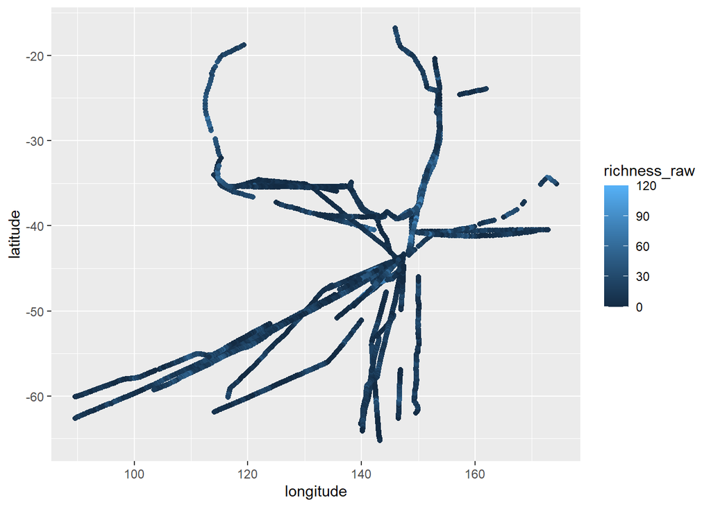

```r
# The first step to making a map using ggplot2is to plot the coordinates for the samples (segments of the CPR silks). The x and y axes are latitude and longitude, just like a map.
ggplot(data) +
  aes(x = longitude, y = latitude, color = richness_raw) +
  geom_point()
```

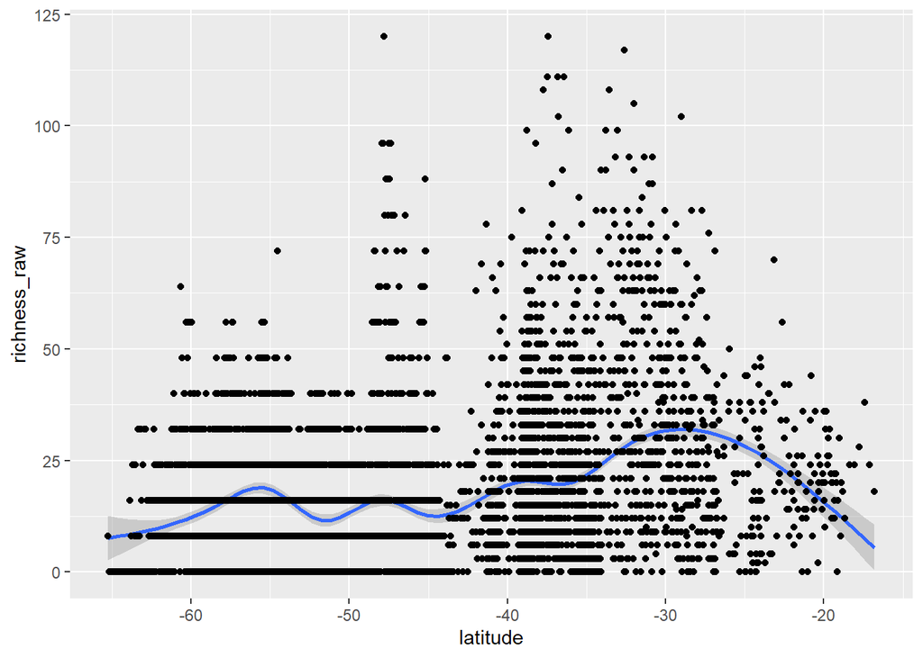

```r
# Now look at richness data (main variable for analysis) in a non-spatial way with latitude on the x-axis and richness on the y-axis
ggplot(data, aes(x = latitude, y = richness_raw)) +
  stat_smooth() +
  geom_point()
```

## B) Maps in R (coordinate reference systems):

### I assigned a coordinate reference system (CRS) to my copepod data to account for the Earth’s curved, 3D shape when mapping in 2D. I used the widely accepted WGS84 system, which represents locations using longitude and latitude in decimal degrees, and defined it in R using the EPSG code 4326. This allowed me to accurately place my sampling points on the globe and ensured compatibility with other spatial data and basemaps.

```r
sdata<- st_as_sf(data, coords = c("longitude", "latitude"),
                 crs = 4326)

##st_as_sf converts different data types to simple features.
## data is our original data.
##coords gives the names of the columns that relate to the spatial coordinates (in order of X coordinate followed by Y coordinate).
## crs stands for coordinate reference system

crs4326 <- st_crs(4326)
crs4326 # look at the whole CRS
crs4326$Name # pull out just the name of the crs
## [1] "WGS 84"

crs4326$wkt # crs in well-known text format
```

### When mapping in WGS84, I assumed degrees were linear units, even though they are actually angular. To improve spatial accuracy, I learned that data should be projected from 3D to 2D using a projected coordinate reference system (PCS). The choice of projection depends on the region and whether I want to preserve angles, distances, or area. R handles this using the PROJ software, and the `"crs"` package can help suggest the best projection for a given dataset.

## C) Feature collection:

```r
sdata
```

[output not shown]

### After converting my data to a simple features object (sf), it looked similar to a regular dataframe but included a new geometry column that stores the spatial coordinates. This format allows me to use typical data wrangling functions like inner_join, as well as plotting and modelling tools like ggplot2 and glm. The sf package also enables spatial-specific operations, such as st_join, which uses coordinate-based logic. In essence, an sf object is like a shapefile—it’s a table that’s spatially aware, with additional information about geometry type and coordinate systems.

## D) Cartography:

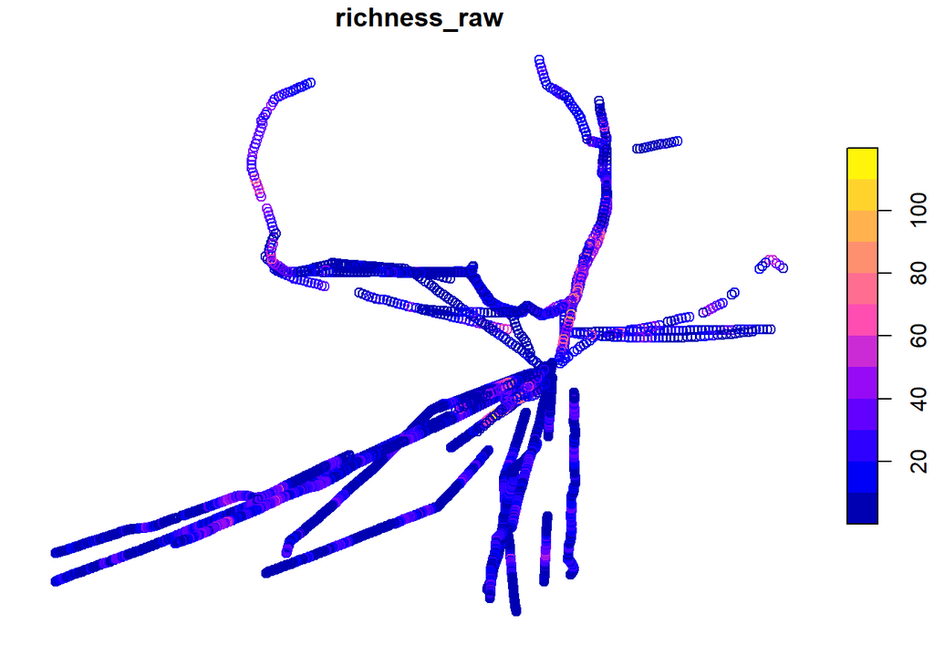

```r
# Plot only using richness column (with single brackets)
plot(sdata["richness_raw"])
```

```r
#using tmap

tmap_richness_raw <- tm_shape(sdata) +
  tm_dots(
    fill = "richness_raw",  # use 'fill' instead of 'col' in tmap v4
    fill.scale = tm_scale_intervals(
      style = "quantile",   # auto-group into quantile bins
      n = 5,                # number of bins (you can adjust this)
      values = "viridis"    # colour palette (e.g., "viridis", "plasma", "Blues")
    ),
    size = 0.1              # dot size
  )

# tm_dots to plot dots of the coordinates. Other options are tm_polygons, tm_symbols
# "richness_raw" is the color scale
```

```r
# Save the map as a JPEG to your output folder
tmap_save(tmap_richness_raw,
          filename = "C:/Users/Adrianna/Documents/AUSTRALIA/JCU/MY CLASSES/Year 2 SEM 1/MB5370 - Marine Techniques 1/MB5370 Module 4 (Data Science in R)/output/Richness-map.jpeg",
          width = 600, height = 600)
```

## E) Mapping spatial polygons as layers:

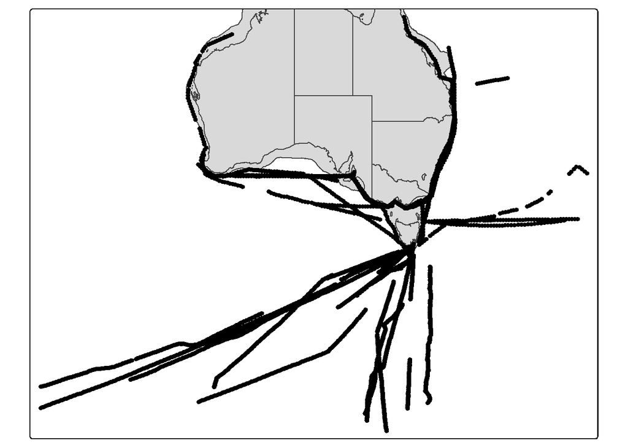

```r
# Load the Australian polygon shapefile
aus <- st_read("data/Workshop4data/spatial-data/Aussie/Aussie.shp")

shelf <- st_read("data/Workshop4data/spatial-data/aus_shelf/aus_shelf.shp")

aus

# Map polygons
tm_shape(shelf, bbox = sdata) +
  tm_polygons() +
  tm_shape(aus) +
  tm_polygons() +
  tm_shape(sdata) +
  tm_dots()
```

### Here, I created a thematic map by layering multiple spatial objects, similar to how plots are built in ggplot2. I started with the continental shelf shapefile and set the bounding box to match my copepod data (sdat) so all points would be visible. I then added the Australia polygon layer on top, followed by my copepod sampling points using tm_dots().

## F) Map customization:

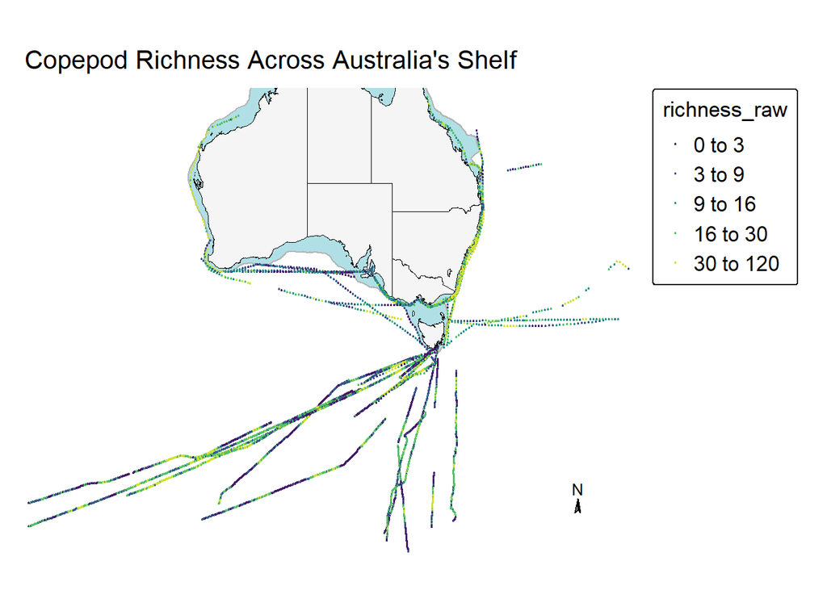

```r
#Explore tmap
vignette('tmap-getstarted')

tm_aus <- tm_shape(shelf, bbox = sdata) +
  tm_polygons(col = "#B0E0E6", border.col = "grey70") +
  tm_shape(aus) +
  tm_polygons(col = "#f5f5f5", border.col = "black", lwd = 0.5) +
  tm_shape(sdata) +
  tm_dots(
    fill = "richness_raw",
    fill.scale = tm_scale_intervals(style = "quantile", n = 5, values = "viridis"),
    size = 0.1
  ) +
  tm_title("Copepod Richness Across Australia's Shelf") +
  tm_layout(
    legend.text.size = 1.05,
    legend.title.size = 1.1,
    frame = FALSE,
    bg.color = "white"
  ) +
  tm_compass(position = c(0.88, 0.18), size = 0.75)

tm_aus
```

```r
# Save the map
tmap_save(tm_aus,
          filename = "C:/Users/Adrianna/Documents/AUSTRALIA/JCU/MY CLASSES/Year 2 SEM 1/MB5370 - Marine Techniques 1/MB5370 Module 4 (Data Science in R)/output/Australia-Copepod-Map.jpeg",
          width = 800, height = 600)
```

```r
# Make sure the CRS matches
rsst <- rast("data/Workshop4data/spatial-data/MeanAVHRRSST/MeanAVHRRSST.grd")
sdat_std <- st_read("data/Workshop4data/spatial-data/copepods_standardised.csv")

# Convert to sf object (wth 'longitude' and 'latitude' columns)
sdat_std <- st_as_sf(sdat_std, coords = c("longitude", "latitude"), crs = 4326)

# Convert to terra SpatVector
sdat_vect <- vect(sdat_std)

# Extract SST values at point locations
sdat_std$sst <- extract(rsst, sdat_vect)[,2]

# Check results
head(sdat_std)
```

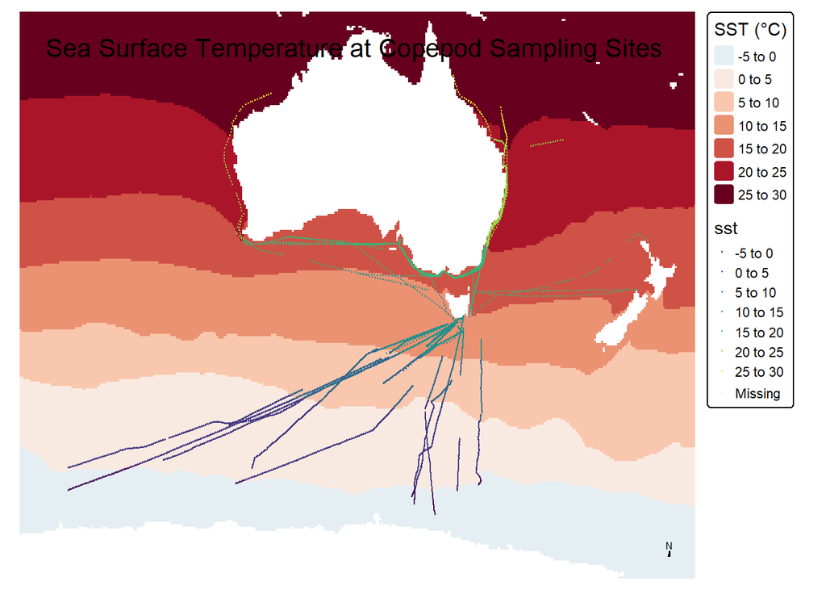

```r
#Make map with SST sampled at each point:

tmap_mode("plot")

tm_sst_map <- tm_shape(rsst) +
  tm_raster(title = "SST (°C)", palette = "-RdBu") +
  tm_shape(sdat_std) +
  tm_dots(col = "sst", size = 0.08, palette = "viridis", title = "Sampled SST") +
  tm_layout(
    title = "Sea Surface Temperature at Copepod Sampling Sites",
    legend.outside = TRUE,
    frame = FALSE
  ) +
  tm_compass(position = c("right", "bottom"), size = 0.5, text.size = 0.5)

tm_sst_map
```

```r
# Save the map
tmap_save(tm_sst_map,
          filename = "C:/Users/Adrianna/Documents/AUSTRALIA/JCU/MY CLASSES/Year 2 SEM 1/MB5370 - Marine Techniques 1/MB5370 Module 4 (Data Science in R)/output/Australia-Surface-Temp-Copepod-Map.jpeg",
          width = 800, height = 600)
```